# What affects borrower's APR?

## Preliminary Wrangling

> This dataset shows an extensive breakdown for loans listing for loans

```python
# import all packages and set plots to be embedded inline
import numpy as np
import pandas as pd
import matplotlib.pyplot as plt
import seaborn as sb

%matplotlib inline
```

```python
df = pd.read_csv('prosperLoanData.csv')
```

```python
df.head()
```

|  | ListingKey | ListingNumber | ListingCreationDate | CreditGrade | Term | LoanStatus | ClosedDate | BorrowerAPR | BorrowerRate | LenderYield | ... | LP_ServiceFees | LP_CollectionFees | LP_GrossPrincipalLoss | LP_NetPrincipalLoss | LP_NonPrincipalRecoverypayments | PercentFunded | Recommendations | InvestmentFromFriendsCount | InvestmentFromFriendsAmount | Investors |
| --- | --- | --- | --- | --- | --- | --- | --- | --- | --- | --- | --- | --- | --- | --- | --- | --- | --- | --- | --- | --- | --- |
| 0 | 1021339766868145413AB3B | 193129 | 2007-08-26 19:09:29.263000000 | C | 36 | Completed | 2009-08-14 00:00:00 | 0.16516 | 0.1580 | 0.1380 | ... | -133.18 | 0.0 | 0.0 | 0.0 | 0.0 | 1.0 | 0 | 0 | 0.0 | 258 |
| 1 | 10273602499503308B223C1 | 1209647 | 2014-02-27 08:28:07.900000000 | NaN | 36 | Current | NaN | 0.12016 | 0.0920 | 0.0820 | ... | 0.00 | 0.0 | 0.0 | 0.0 | 0.0 | 1.0 | 0 | 0 | 0.0 | 1 |
| 2 | 0EE9337825851032864889A | 81716 | 2007-01-05 15:00:47.090000000 | HR | 36 | Completed | 2009-12-17 00:00:00 | 0.28269 | 0.2750 | 0.2400 | ... | -24.20 | 0.0 | 0.0 | 0.0 | 0.0 | 1.0 | 0 | 0 | 0.0 | 41 |
| 3 | 0EF5356002482715299901A | 658116 | 2012-10-22 11:02:35.010000000 | NaN | 36 | Current | NaN | 0.12528 | 0.0974 | 0.0874 | ... | -108.01 | 0.0 | 0.0 | 0.0 | 0.0 | 1.0 | 0 | 0 | 0.0 | 158 |
| 4 | 0F023589499656230C5E3E2 | 909464 | 2013-09-14 18:38:39.097000000 | NaN | 36 | Current | NaN | 0.24614 | 0.2085 | 0.1985 | ... | -60.27 | 0.0 | 0.0 | 0.0 | 0.0 | 1.0 | 0 | 0 | 0.0 | 20 |

5 rows × 81 columns

```python
df = df[~df['ListingNumber'].duplicated()]
df['ListingCreationDate'] = pd.to_datetime(df['ListingCreationDate'])
df = df.rename(columns={"ProsperRating (numeric)": "ProsperRating_numeric",
                        "ProsperRating (Alpha)": "ProsperRating_alpha",'ListingCategory (numeric)':'ListingCategory'})
df = df[df['ProsperRating_alpha'].notnull() & df['Occupation'].notnull() & df['EmploymentStatusDuration'].notnull()]
```

```python
df = df[['ListingNumber',
'ListingCreationDate',
'Term',
'BorrowerAPR',
'ProsperRating_alpha',
'ProsperScore',
'ListingCategory',
'Occupation',
'EmploymentStatus',
'EmploymentStatusDuration',
'IsBorrowerHomeowner',
'CreditScoreRangeUpper',
'CurrentCreditLines',
'OpenCreditLines',
'IncomeRange',
'StatedMonthlyIncome',
'LoanOriginalAmount']]
```

```python
prosper_classes = ['HR', 'E', 'D', 'C', 'B','A','AA']
PRatings = pd.api.types.CategoricalDtype(ordered=True, categories = prosper_classes)
df['ProsperRating_alpha'] = df['ProsperRating_alpha'].astype(PRatings);

income_classes = ['Not employed', '$0', '$1-24,999', '$25,000-49,999', '$50,000-74,999','$75,000-99,999','$100,000+']
incomeCategories = pd.api.types.CategoricalDtype(ordered=True, categories = income_classes)
df['IncomeRange'] = df['IncomeRange'].astype(incomeCategories);

df['CreditScoreRangeUpper'] = df['CreditScoreRangeUpper'].astype(str).str[:-2]
creditScore_classes = ['619', '639', '659', '679', '699','719','739','759','779','799','819','839','859','879','899']
creditCategories = pd.api.types.CategoricalDtype(ordered=True, categories = creditScore_classes)
df['CreditScoreRangeUpper'] = df['CreditScoreRangeUpper'].astype(creditCategories);



df['ListingCategory'] = df['ListingCategory'].astype(str)
df['ListingNumber'] = df['ListingNumber'].astype(str)



df['ProsperScore'] = df['ProsperScore'].astype(str).str[:-2]
prosperScore_classes = ['1', '2', '3', '4', '5','6','7','8','9','10','11']
prosperCategories = pd.api.types.CategoricalDtype(ordered=True, categories = prosperScore_classes)
df['ProsperScore'] = df['ProsperScore'].astype(prosperCategories);



df['Term'] = df['Term'].astype(str)
term_classes = ['12', '36', '60']
termCategories = pd.api.types.CategoricalDtype(ordered=True, categories = term_classes)
df['Term'] = df['Term'].astype(termCategories);
```

```python
df['IncomeRange'].value_counts()
```

```
$50,000-74,999    25002
$25,000-49,999    23344
$100,000+         15016
$75,000-99,999    14270
$1-24,999          4369
Not employed        649
$0                   45
Name: IncomeRange, dtype: int64
```

```python
df.info()
```

```
<class 'pandas.core.frame.DataFrame'>
Int64Index: 82695 entries, 1 to 113936
Data columns (total 17 columns):
 #   Column                    Non-Null Count  Dtype
---  ------                    --------------  -----
 0   ListingNumber             82695 non-null  object
 1   ListingCreationDate       82695 non-null  datetime64[ns]
 2   Term                      82695 non-null  category
 3   BorrowerAPR               82695 non-null  float64
 4   ProsperRating_alpha       82695 non-null  category
 5   ProsperScore              82695 non-null  category
 6   ListingCategory           82695 non-null  object
 7   Occupation                82695 non-null  object
 8   EmploymentStatus          82695 non-null  object
 9   EmploymentStatusDuration  82695 non-null  float64
 10  IsBorrowerHomeowner       82695 non-null  bool
 11  CreditScoreRangeUpper     82695 non-null  category
 12  CurrentCreditLines        82695 non-null  float64
 13  OpenCreditLines           82695 non-null  float64
 14  IncomeRange               82695 non-null  category
 15  StatedMonthlyIncome       82695 non-null  float64
 16  LoanOriginalAmount        82695 non-null  int64
dtypes: bool(1), category(5), datetime64[ns](1), float64(5), int64(1), object(4)
memory usage: 8.0+ MB
```

```python
df['CreditScoreRangeUpper'].value_counts()
```

```
699    13606
679    13592
719    13255
739    10774
659     8526
759     7755
779     5171
799     3669
819     2083
639     1650
619     1039
839     1038
859      398
879      122
899       17
Name: CreditScoreRangeUpper, dtype: int64
```

```python
df['BorrowerAPR'].value_counts()
```

```
0.35797    3671
0.35643    1644
0.30532     902
0.29510     747
0.35356     689
           ...
0.21933       1
0.16957       1
0.27068       1
0.08732       1
0.38037       1
Name: BorrowerAPR, Length: 2329, dtype: int64
```

```python
df['ProsperScore'].value_counts()
```

```
4     12116
6     12016
8     11846
7     10347
5      9605
3      7365
9      6826
2      5567
10     4652
11     1411
1       944
Name: ProsperScore, dtype: int64
```

```python
df['CurrentCreditLines'].value_counts()
```

```
8.0     7187
9.0     7046
7.0     7014
10.0    6581
11.0    6151
6.0     5722
12.0    5293
5.0     4837
13.0    4565
14.0    3950
4.0     3364
15.0    3196
16.0    2781
3.0     2344
17.0    2076
18.0    1790
2.0     1474
19.0    1391
20.0    1094
21.0     843
1.0      723
22.0     642
23.0     508
24.0     421
25.0     339
26.0     268
0.0      219
27.0     190
28.0     155
29.0     116
30.0      90
31.0      66
32.0      53
33.0      49
34.0      32
35.0      30
36.0      27
37.0      18
38.0      16
39.0       9
40.0       7
54.0       3
41.0       3
47.0       2
42.0       2
56.0       2
45.0       2
44.0       1
59.0       1
43.0       1
48.0       1
Name: CurrentCreditLines, dtype: int64
```

```python
#Change the listing from numerical values to the corresponding category value
dictCategory = {'0': 'Not Available',
        '1': 'Debt Consolidation',
        '2': 'Home Improvement',
        '3': 'Business',
         '4': 'Personal Loan',
         '5':'Student Use',
         '6':'Auto',
         '7':'Other',
         '8':'Baby&Adoption',
         '9':'Boat',
         '10':'Cosmetic Procedure',
         '11':'Engagement Ring',
         '12':'Green Loans',
         '13':'Household Expenses',
         '14':'Large Purchases',
         '15':'Medical/Dental',
         '16':'Motorcycle',
         '17':'RV',
         '18':'Taxes',
         '19':'Vacation',
         '20':'Wedding Loans',
        }
def change_category(df):
    if df['ListingCategory'] in dictCategory.keys():
        strCategory = dictCategory[df['ListingCategory']]
        return strCategory
    else:
        return df['ListingCategory']

df['ListingCategory'] = df.apply(change_category, axis=1)
```

```python
df['Occupation'].value_counts().head(50)
```

```
Other                                21122
Professional                         10442
Executive                             3437
Computer Programmer                   3200
Teacher                               2858
Analyst                               2711
Administrative Assistant              2696
Accountant/CPA                        2550
Sales - Commission                    2318
Skilled Labor                         2156
Nurse (RN)                            2145
Clerical                              2085
Sales - Retail                        2012
Retail Management                     1975
Truck Driver                          1357
Construction                          1313
Police Officer/Correction Officer     1259
Laborer                               1200
Civil Service                         1127
Engineer - Mechanical                 1126
Food Service Management                993
Engineer - Electrical                  893
Medical Technician                     879
Attorney                               853
Food Service                           829
Military Enlisted                      817
Tradesman - Mechanic                   783
Social Worker                          566
Postal Service                         482
Professor                              450
Nurse (LPN)                            414
Doctor                                 391
Tradesman - Electrician                382
Nurse's Aide                           379
Fireman                                318
Waiter/Waitress                        292
Scientist                              287
Principal                              257
Bus Driver                             248
Military Officer                       247
Realtor                                244
Pharmacist                             223
Investor                               200
Teacher's Aide                         199
Engineer - Chemical                    173
Landscaping                            170
Clergy                                 156
Pilot - Private/Commercial             152
Architect                              148
Car Dealer                             140
Name: Occupation, dtype: int64
```

```python
occupation_15 = df.query('Occupation != "Other"')['Occupation'].value_counts().head(15).index
```

```python
df_top15_occupation = df[df['Occupation'].isin(occupation_15)]
```

```python
df.info()
```

```
<class 'pandas.core.frame.DataFrame'>
Int64Index: 82695 entries, 1 to 113936
Data columns (total 17 columns):
 #   Column                    Non-Null Count  Dtype
---  ------                    --------------  -----
 0   ListingNumber             82695 non-null  object
 1   ListingCreationDate       82695 non-null  datetime64[ns]
 2   Term                      82695 non-null  category
 3   BorrowerAPR               82695 non-null  float64
 4   ProsperRating_alpha       82695 non-null  category
 5   ProsperScore              82695 non-null  category
 6   ListingCategory           82695 non-null  object
 7   Occupation                82695 non-null  object
 8   EmploymentStatus          82695 non-null  object
 9   EmploymentStatusDuration  82695 non-null  float64
 10  IsBorrowerHomeowner       82695 non-null  bool
 11  CreditScoreRangeUpper     82695 non-null  category
 12  CurrentCreditLines        82695 non-null  float64
 13  OpenCreditLines           82695 non-null  float64
 14  IncomeRange               82695 non-null  category
 15  StatedMonthlyIncome       82695 non-null  float64
 16  LoanOriginalAmount        82695 non-null  int64
dtypes: bool(1), category(5), datetime64[ns](1), float64(5), int64(1), object(4)
memory usage: 8.0+ MB
```

### What is the structure of your dataset?

> The dataset consists of 7 numeric variables and 10 categorical variable.

### What is/are the main feature(s) of interest in your dataset?

> BorrowerAPR and income range and occupation and employment status are my main featues of interest are what we want to predict and find what could come handy in predicting them.

### What features in the dataset do you think will help support your investigation into your feature(s) of interest?

- ListingNumber
- ListingCreationDate
- Term
- ProsperRating_alpha
- ProsperScore
- ListingCategory
- EmploymentStatusDuration
- IsBorrowerHomeowner
- CreditScoreRangeUpper
- CurrentCreditLines
- OpenCreditLines
- StatedMonthlyIncome
- LoanOriginalAmount

## Univariate Exploration

```python
df.info()
```

```
<class 'pandas.core.frame.DataFrame'>
Int64Index: 82695 entries, 1 to 113936
Data columns (total 17 columns):
 #   Column                    Non-Null Count  Dtype
---  ------                    --------------  -----
 0   ListingNumber             82695 non-null  object
 1   ListingCreationDate       82695 non-null  datetime64[ns]
 2   Term                      82695 non-null  category
 3   BorrowerAPR               82695 non-null  float64
 4   ProsperRating_alpha       82695 non-null  category
 5   ProsperScore              82695 non-null  category
 6   ListingCategory           82695 non-null  object
 7   Occupation                82695 non-null  object
 8   EmploymentStatus          82695 non-null  object
 9   EmploymentStatusDuration  82695 non-null  float64
 10  IsBorrowerHomeowner       82695 non-null  bool
 11  CreditScoreRangeUpper     82695 non-null  category
 12  CurrentCreditLines        82695 non-null  float64
 13  OpenCreditLines           82695 non-null  float64
 14  IncomeRange               82695 non-null  category
 15  StatedMonthlyIncome       82695 non-null  float64
 16  LoanOriginalAmount        82695 non-null  int64
dtypes: bool(1), category(5), datetime64[ns](1), float64(5), int64(1), object(4)
memory usage: 8.0+ MB
```

```
array([[<AxesSubplot:title={'center':'BorrowerAPR'}>,
        <AxesSubplot:title={'center':'EmploymentStatusDuration'}>],
       [<AxesSubplot:title={'center':'OpenCreditLines'}>,
        <AxesSubplot:title={'center':'LoanOriginalAmount'}>]],
      dtype=object)
```

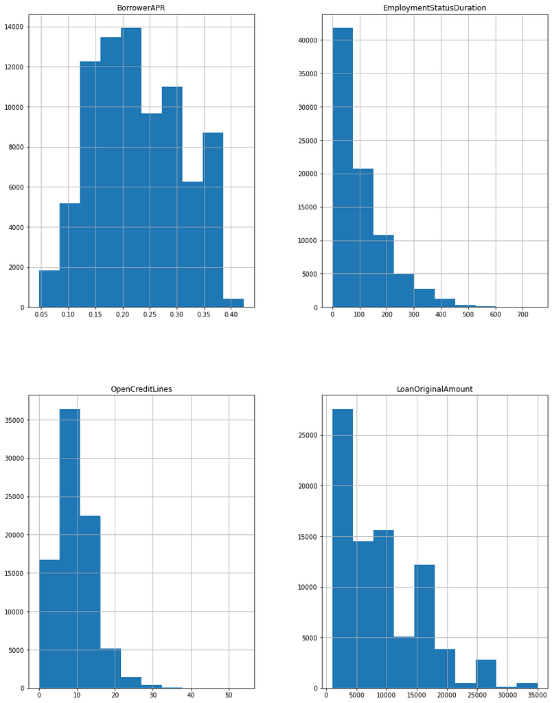

```python
fig = plt.figure(figsize = (15,20))
ax = fig.gca()
df[['Term','BorrowerAPR','EmploymentStatusDuration','OpenCreditLines','LoanOriginalAmount']].hist(ax = ax)
```

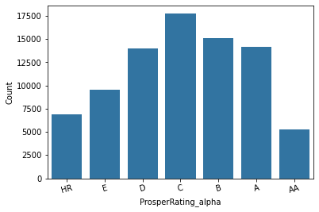

```python
base_color = sb.color_palette()[0]
sb.countplot(data=df, x='ProsperRating_alpha', color=base_color)
plt.xticks(rotation=15);
plt.ylabel('Count')
```

```python
df.info()
```

```
<class 'pandas.core.frame.DataFrame'>
Int64Index: 82695 entries, 1 to 113936
Data columns (total 17 columns):
 #   Column                    Non-Null Count  Dtype
---  ------                    --------------  -----
 0   ListingNumber             82695 non-null  object
 1   ListingCreationDate       82695 non-null  datetime64[ns]
 2   Term                      82695 non-null  category
 3   BorrowerAPR               82695 non-null  float64
 4   ProsperRating_alpha       82695 non-null  category
 5   ProsperScore              82695 non-null  category
 6   ListingCategory           82695 non-null  object
 7   Occupation                82695 non-null  object
 8   EmploymentStatus          82695 non-null  object
 9   EmploymentStatusDuration  82695 non-null  float64
 10  IsBorrowerHomeowner       82695 non-null  bool
 11  CreditScoreRangeUpper     82695 non-null  category
 12  CurrentCreditLines        82695 non-null  float64
 13  OpenCreditLines           82695 non-null  float64
 14  IncomeRange               82695 non-null  category
 15  StatedMonthlyIncome       82695 non-null  float64
 16  LoanOriginalAmount        82695 non-null  int64
dtypes: bool(1), category(5), datetime64[ns](1), float64(5), int64(1), object(4)
memory usage: 10.1+ MB
```

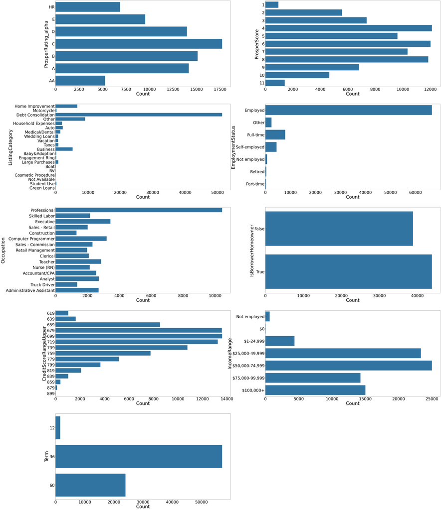

```python
BarChartsItems = ['ProsperRating_alpha','ProsperScore', 'ListingCategory','EmploymentStatus','Occupation',
                 'IsBorrowerHomeowner','CreditScoreRangeUpper','IncomeRange','Term']
def multiple_bars(df,occupation_df):
    plt.figure(figsize = [60, 80])
    for i in range(len(BarChartsItems)):
        if BarChartsItems[i] == 'Occupation':
            plt.subplot(5, 2, i + 1)
            base_color = sb.color_palette()[0]
            sb.countplot(data=occupation_df, y=BarChartsItems[i], color=base_color)
            plt.xlabel('Count',fontsize=40)
            plt.ylabel(BarChartsItems[i], fontsize=40)
            plt.yticks(fontsize=35)
            plt.xticks(fontsize=35);
        else:
            plt.subplot(5, 2, i + 1)
            base_color = sb.color_palette()[0]
            sb.countplot(data=df, y=BarChartsItems[i], color=base_color)
            plt.xlabel('Count',fontsize=40)
            plt.ylabel(BarChartsItems[i], fontsize=40)
            plt.yticks(fontsize=35)
            plt.xticks(fontsize=35);

multiple_bars(df,df_top15_occupation)
```

```python
df['BorrowerAPR'].describe()
```

```
count    82695.000000
mean         0.227143
std          0.080239
min          0.045830
25%          0.163610
50%          0.220290
75%          0.293340
max          0.423950
Name: BorrowerAPR, dtype: float64
```

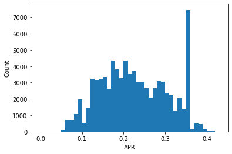

```python
bins = np.arange(0, df['BorrowerAPR'].max()+0.01, 0.01)
plt.hist(data = df, x = 'BorrowerAPR', bins=bins)
plt.ylabel("Count")
plt.xlabel("APR")
```

The histogram shows data that could look to be normally distributed at first sight but there appears to be a very repeatted value which we may need to look at. So now let's look at the mode

```python
df['BorrowerAPR'].mode()
```

```
0    0.35797
dtype: float64
```

```python
df.query('BorrowerAPR == 0.35797')['ProsperRating_alpha'].value_counts()
```

```
HR    3671
E        0
D        0
C        0
B        0
A        0
AA       0
Name: ProsperRating_alpha, dtype: int64
```

```python
df.query('BorrowerAPR == 0.35797')['ProsperScore'].value_counts()
```

```
4     1284
5     1095
3      724
2      306
6      164
1       98
7        0
8        0
9        0
10       0
11       0
Name: ProsperScore, dtype: int64
```

It appears that the repeated value of APR is associated with only one Prosper Rating "HR" which is the lowest rating. So I'd assume that this APR is given with higher risk customers. Let's do a more graphs

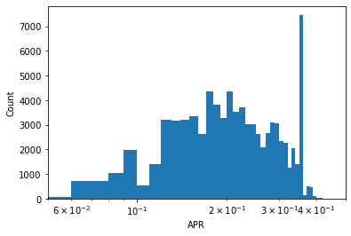

```python
bins = np.arange(0, df['BorrowerAPR'].max()+0.01, 0.01)
plt.hist(data = df, x = 'BorrowerAPR', bins=bins)
plt.ylabel("Count")
plt.xlabel("APR")
plt.xscale('log')
plt.xlim((0.05,0.5));
```

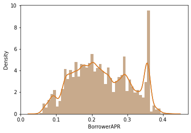

```python
sb.distplot(df['BorrowerAPR'])

# Set the argument `kde=False` to remove the estimate-line representing the Gaussian kernel density estimate.
sb.distplot(df['BorrowerAPR'], kde=True)
```

```python
np.log10(df.query('EmploymentStatusDuration != 0')['EmploymentStatusDuration'].describe())
```

```
count    4.914756
mean     2.017202
std      1.983025
min      0.000000
25%      1.505150
50%      1.875061
75%      2.173186
max      2.877947
Name: EmploymentStatusDuration, dtype: float64
```

**Due to the repeated value I wanted to check if the graph could be skewed to the right so I scaled the APR values and it doesn't look to be the case.**

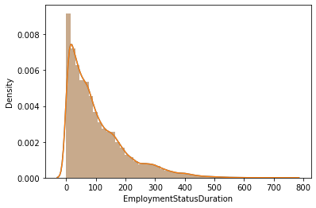

```python
sb.distplot(df['EmploymentStatusDuration'])

# Set the argument `kde=False` to remove the estimate-line representing the Gaussian kernel density estimate.
sb.distplot(df['EmploymentStatusDuration'], kde=True)
```

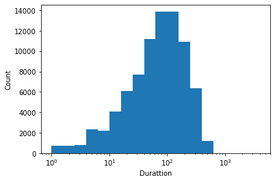

```python
bins = 10 ** np.arange(0, 2.8 + 1, 0.2)
plt.hist(data = df, x = 'EmploymentStatusDuration', bins=bins)
plt.ylabel("Count")
plt.xlabel("Durattion")
plt.xscale('log')
```

Since the Employment Duration seemed to be skewed to the right I scaled the duration value to the natural log of 10 which resulted in a grapgh that is somewhat skewed to the left and somewhat normally distributed

### Discuss the distribution(s) of your variable(s) of interest. Were there any unusual points? Did you need to perform any transformations?

> Employment Duration and loan amount appear to be skewed to the right and borrower's APR looks to be closer to normal distrbution. I did a log scale to the Employment duration since the graph looked to be skewed to the right and the obtained graph looked to be somewhat normally distributed

### Of the features you investigated, were there any unusual distributions? Did you perform any operations on the data to tidy, adjust, or change the form of the data? If so, why did you do this?

> The borrower's APR seemed to look different around 0.35797 and on further invistigation, the value seem to be associated with lower Prosper Rating. Which could mean it's often given with higher risk borrowers

```python
df.info()
```

```
<class 'pandas.core.frame.DataFrame'>
Int64Index: 82695 entries, 1 to 113936
Data columns (total 17 columns):
 #   Column                    Non-Null Count  Dtype
---  ------                    --------------  -----
 0   ListingNumber             82695 non-null  object
 1   ListingCreationDate       82695 non-null  datetime64[ns]
 2   Term                      82695 non-null  category
 3   BorrowerAPR               82695 non-null  float64
 4   ProsperRating_alpha       82695 non-null  category
 5   ProsperScore              82695 non-null  category
 6   ListingCategory           82695 non-null  object
 7   Occupation                82695 non-null  object
 8   EmploymentStatus          82695 non-null  object
 9   EmploymentStatusDuration  82695 non-null  float64
 10  IsBorrowerHomeowner       82695 non-null  bool
 11  CreditScoreRangeUpper     82695 non-null  category
 12  CurrentCreditLines        82695 non-null  float64
 13  OpenCreditLines           82695 non-null  float64
 14  IncomeRange               82695 non-null  category
 15  StatedMonthlyIncome       82695 non-null  float64
 16  LoanOriginalAmount        82695 non-null  int64
dtypes: bool(1), category(5), datetime64[ns](1), float64(5), int64(1), object(4)
memory usage: 10.1+ MB
```

## Bivariate Exploration

> In this section, investigate relationships between pairs of variables in your data. Make sure the variables that you cover here have been introduced in some fashion in the previous section (univariate exploration).

```python
df['StatedMonthlyIncome'].max()
```

```
1750002.916667
```

```python
df[df['StatedMonthlyIncome'] == df['StatedMonthlyIncome'].max()]
```

|  | ListingNumber | ListingCreationDate | Term | BorrowerAPR | ProsperRating_alpha | ProsperScore | ListingCategory | Occupation | EmploymentStatus | EmploymentStatusDuration | IsBorrowerHomeowner | CreditScoreRangeUpper | CurrentCreditLines | OpenCreditLines | IncomeRange | StatedMonthlyIncome | LoanOriginalAmount |
| --- | --- | --- | --- | --- | --- | --- | --- | --- | --- | --- | --- | --- | --- | --- | --- | --- | --- |
| 53167 | 560783 | 2012-02-20 12:53:44.577 | 36 | 0.35797 | HR | 4 | Business | Professional | Self-employed | 114.0 | True | 759 | 19.0 | 17.0 | $100,000+ | 1.750003e+06 | 4000 |

```python
df['StatedMonthlyIncome'].describe()
```

```
count    8.269500e+04
mean     5.964898e+03
std      8.324027e+03
min      0.000000e+00
25%      3.500000e+03
50%      5.000000e+03
75%      7.166667e+03
max      1.750003e+06
Name: StatedMonthlyIncome, dtype: float64
```

```python
df['BorrowerAPR'].describe()
```

```
count    82695.000000
mean         0.227143
std          0.080239
min          0.045830
25%          0.163610
50%          0.220290
75%          0.293340
max          0.423950
Name: BorrowerAPR, dtype: float64
```

```python
df = df.drop([53167])
```

```
(1000.0, 6000.0)
```

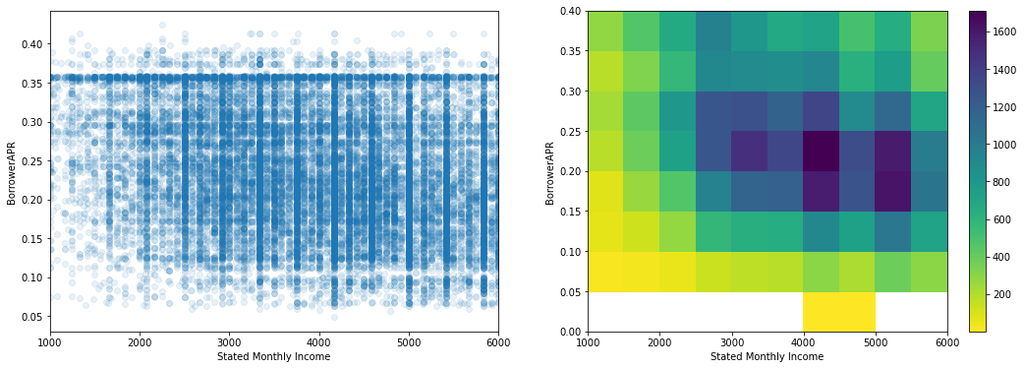

```python
plt.figure(figsize = [18, 6])

# PLOT ON LEFT
plt.subplot(1, 2, 1)
plt.scatter(data = df.sample(40000), x = 'StatedMonthlyIncome', y = 'BorrowerAPR', alpha = 1/10);
plt.xlim(1000,6000)
plt.xlabel('Stated Monthly Income')
plt.ylabel('BorrowerAPR');

# PLOT ON RIGHT
plt.subplot(1, 2, 2)
bins_x = np.arange(0, 7000 + 500, 500)
bins_y = np.arange(0, 0.4 + 0.05, 0.05)
plt.hist2d(data = df, x = 'StatedMonthlyIncome', y = 'BorrowerAPR', cmin=0.5, cmap='viridis_r',bins = [bins_x, bins_y])
plt.colorbar()
plt.xlabel('Stated Monthly Income')
plt.ylabel('BorrowerAPR');
plt.xlim(1000,6000)
```

It was very hard to detrmine what's going on with a scatterplot so I opted to Heatmap. The heatmap suggests that higher monthly income is associated with lower APR.

```python
df['CurrentCreditLines'].describe()
```

```
count    82694.000000
mean        10.501113
std          5.323957
min          0.000000
25%          7.000000
50%         10.000000
75%         13.000000
max         59.000000
Name: CurrentCreditLines, dtype: float64
```

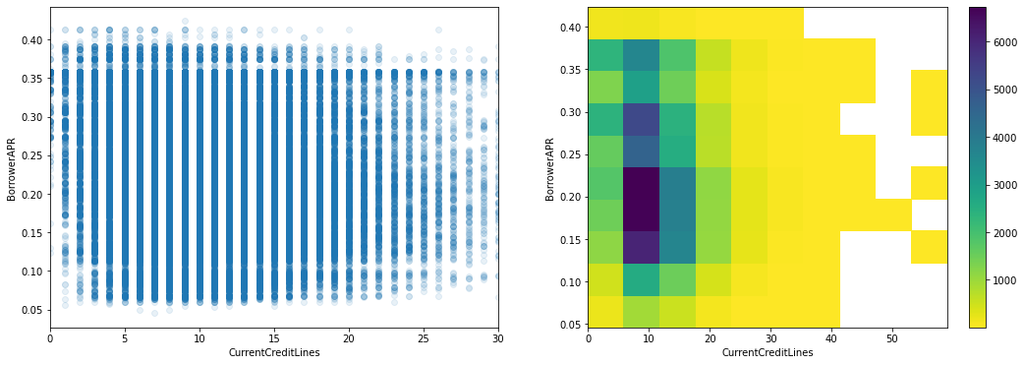

```python
plt.figure(figsize = [18, 6])

# PLOT ON LEFT
plt.subplot(1, 2, 1)
plt.scatter(data = df, x = 'CurrentCreditLines', y = 'BorrowerAPR', alpha = 1/10);
plt.xlim(0,30)
plt.xlabel('CurrentCreditLines')
plt.ylabel('BorrowerAPR');

# PLOT ON RIGHT
plt.subplot(1, 2, 2)
bins_x = np.arange(0, 60 + 5, 5)
bins_y = np.arange(0, 0.4 + 0.05, 0.05)
plt.hist2d(data = df, x = 'CurrentCreditLines', y = 'BorrowerAPR', cmin=0.5, cmap='viridis_r')
plt.colorbar()
plt.xlabel('CurrentCreditLines')
plt.ylabel('BorrowerAPR');
```

**Only when the open and current line credits are around 10 it seems there's a slight advantage of being associated with lower APR**

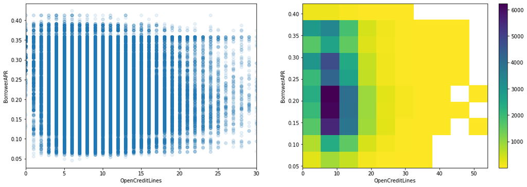

```python
plt.figure(figsize = [18, 6])

# PLOT ON LEFT
plt.subplot(1, 2, 1)
plt.scatter(data = df, x = 'OpenCreditLines', y = 'BorrowerAPR', alpha = 1/10);
plt.xlim(0,30)
plt.xlabel('OpenCreditLines')
plt.ylabel('BorrowerAPR');

# PLOT ON RIGHT
plt.subplot(1, 2, 2)
bins_x = np.arange(0, 60 + 5, 5)
bins_y = np.arange(0, 0.4 + 0.05, 0.05)
plt.hist2d(data = df, x = 'OpenCreditLines', y = 'BorrowerAPR', cmin=0.5, cmap='viridis_r')
plt.colorbar()
plt.xlabel ('OpenCreditLines')
plt.ylabel('BorrowerAPR');
```

**Same as above**

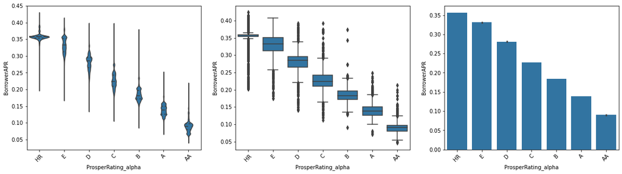

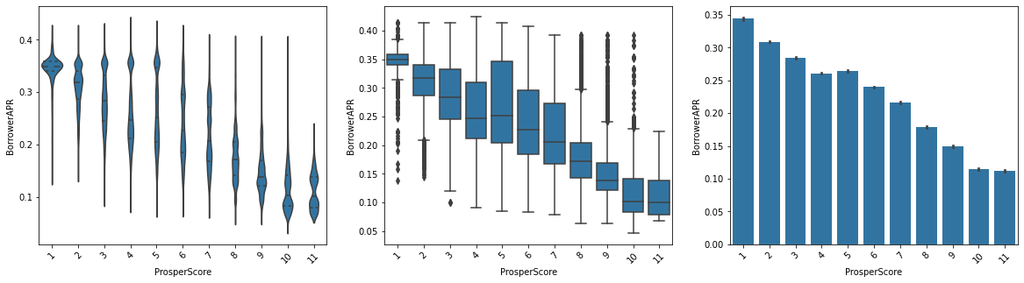

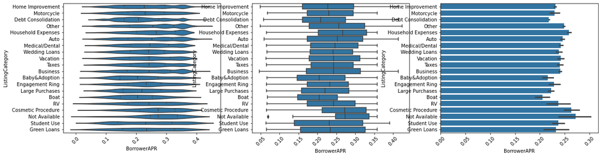

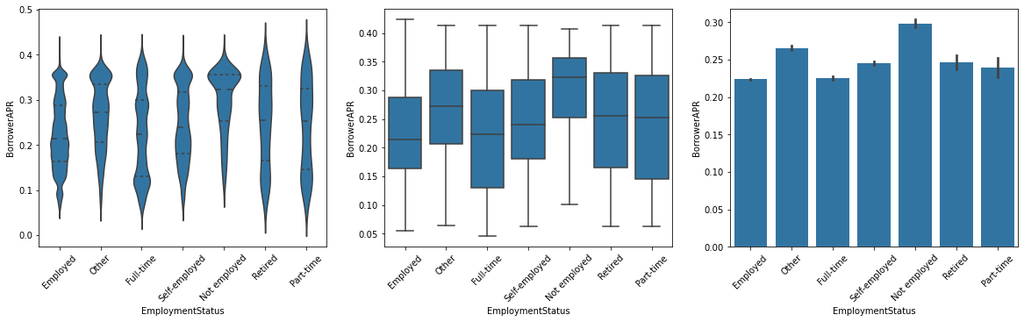

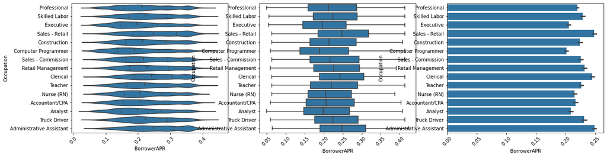

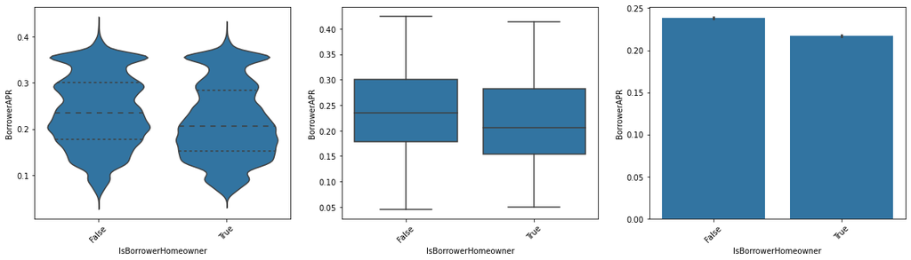

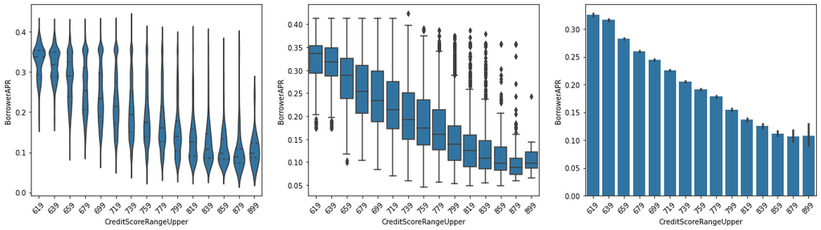

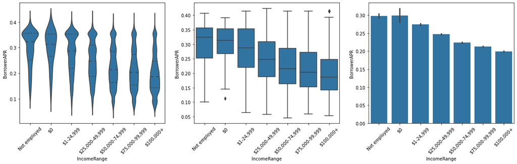

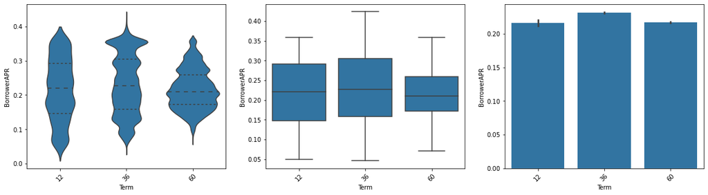

```python
categorical_items = ['ProsperRating_alpha','ProsperScore', 'ListingCategory','EmploymentStatus','Occupation',
                 'IsBorrowerHomeowner','CreditScoreRangeUpper','IncomeRange','Term']
def multiple_bivariate(df,occupation_df):
    for i in categorical_items:
        # bivariate plots of APR vs. categorical variables
        #violin, boxplot, barchart qual vs quant
        if(i == 'ListingCategory'):
            plt.figure(figsize = [20, 5])
            base_color = sb.color_palette()[0]
            # left plot: violin plot
            plt.subplot(1, 3, 1)
            sb.violinplot(data=df, y=i, x='BorrowerAPR', inner = 'quartile', color = base_color)
            plt.xticks(rotation = 45); # include label rotation due to small subplot size

            # center plot: box plot
            plt.subplot(1, 3, 2)
            sb.boxplot(data=df, y=i, x='BorrowerAPR', color = base_color)
            plt.xticks(rotation = 45);

            # right plot: adapted bar chart
            plt.subplot(1, 3, 3)
            sb.barplot(data=df, y=i, x='BorrowerAPR', color = base_color)
            plt.xticks(rotation = 45);
        elif(i == 'Occupation'):
            plt.figure(figsize = [20, 5])
            base_color = sb.color_palette()[0]
            # left plot: violin plot
            plt.subplot(1, 3, 1)
            sb.violinplot(data=df_top15_occupation, y=i, x='BorrowerAPR', inner = 'quartile', color = base_color)
            plt.xticks(rotation = 45); # include label rotation due to small subplot size

            # center plot: box plot
            plt.subplot(1, 3, 2)
            sb.boxplot(data=df_top15_occupation, y=i, x='BorrowerAPR', color = base_color)
            plt.xticks(rotation = 45);

            # right plot: adapted bar chart
            plt.subplot(1, 3, 3)
            sb.barplot(data=df_top15_occupation, y=i, x='BorrowerAPR', color = base_color)
            plt.xticks(rotation = 45);
        else:
            plt.figure(figsize = [20, 5])
            base_color = sb.color_palette()[0]
            # left plot: violin plot
            plt.subplot(1, 3, 1)
            sb.violinplot(data=df, x=i, y='BorrowerAPR', inner = 'quartile', color = base_color)
            plt.xticks(rotation = 45); # include label rotation due to small subplot size

            # center plot: box plot
            plt.subplot(1, 3, 2)
            sb.boxplot(data=df, x=i, y='BorrowerAPR', color = base_color)
            plt.xticks(rotation = 45);

            # right plot: adapted bar chart
            plt.subplot(1, 3, 3)
            sb.barplot(data=df, x=i, y='BorrowerAPR', color = base_color)
            plt.xticks(rotation = 45);


multiple_bivariate(df,df_top15_occupation)
```

**I did boxplot, violinplot, bivariate bar charts for my categorical variables of interest.**

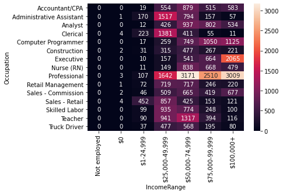

```python
ct_counts = df_top15_occupation.groupby(['Occupation', 'IncomeRange']).size()
ct_counts = ct_counts.reset_index(name='count')
ct_counts = ct_counts.pivot(index = 'Occupation', columns = 'IncomeRange', values = 'count')
sb.heatmap(ct_counts, annot = True, fmt = 'd')
```

I did a heatmap for Occupation vs Income Range since I'm little interested to see what's the breadown of each occupation.

## Multivariate Exploration

> Create plots of three or more variables to investigate your data even further. Make sure that your investigations are justified, and follow from your work in the previous sections.

```
(0.0, 10000.0)
```

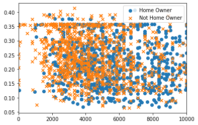

```python
cat_markers = [[True, 'o'],
               [False, 'x']]

for cat, marker in cat_markers:
    df_cat = df[df['IsBorrowerHomeowner'] == cat].sample(1000)
    plt.scatter(data = df_cat, x = 'StatedMonthlyIncome', y = 'BorrowerAPR', marker = marker)
plt.legend(['Home Owner','Not Home Owner'])
plt.xlim(0,10000)
```

This is a multivariate graph where I put monthly income against APR and decided to separate between home owners and none home owners and it appears that it's likely that homeowners get a slightly less APR

```
(1000.0, 6000.0)
```

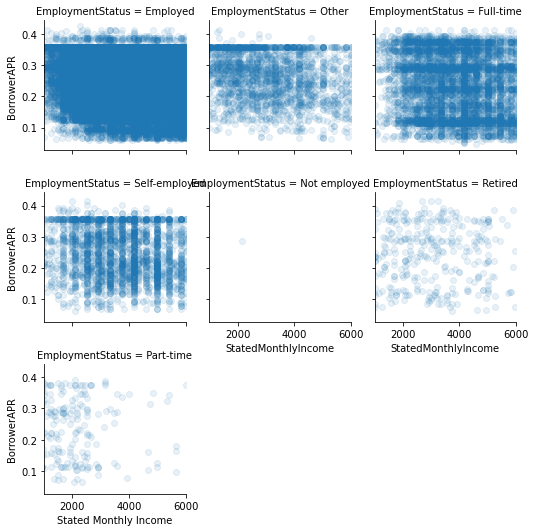

```python
# multivariate plot
g = sb.FacetGrid(data = df, col = 'EmploymentStatus', height = 2.5,
                margin_titles = True, col_wrap = 3)
g.map(plt.scatter, 'StatedMonthlyIncome', 'BorrowerAPR', alpha = 1/10)
plt.ylabel("BorrowerAPR")
plt.xlabel("Stated Monthly Income")
plt.xlim(1000,6000)
```

```
(1000.0, 6000.0)
```

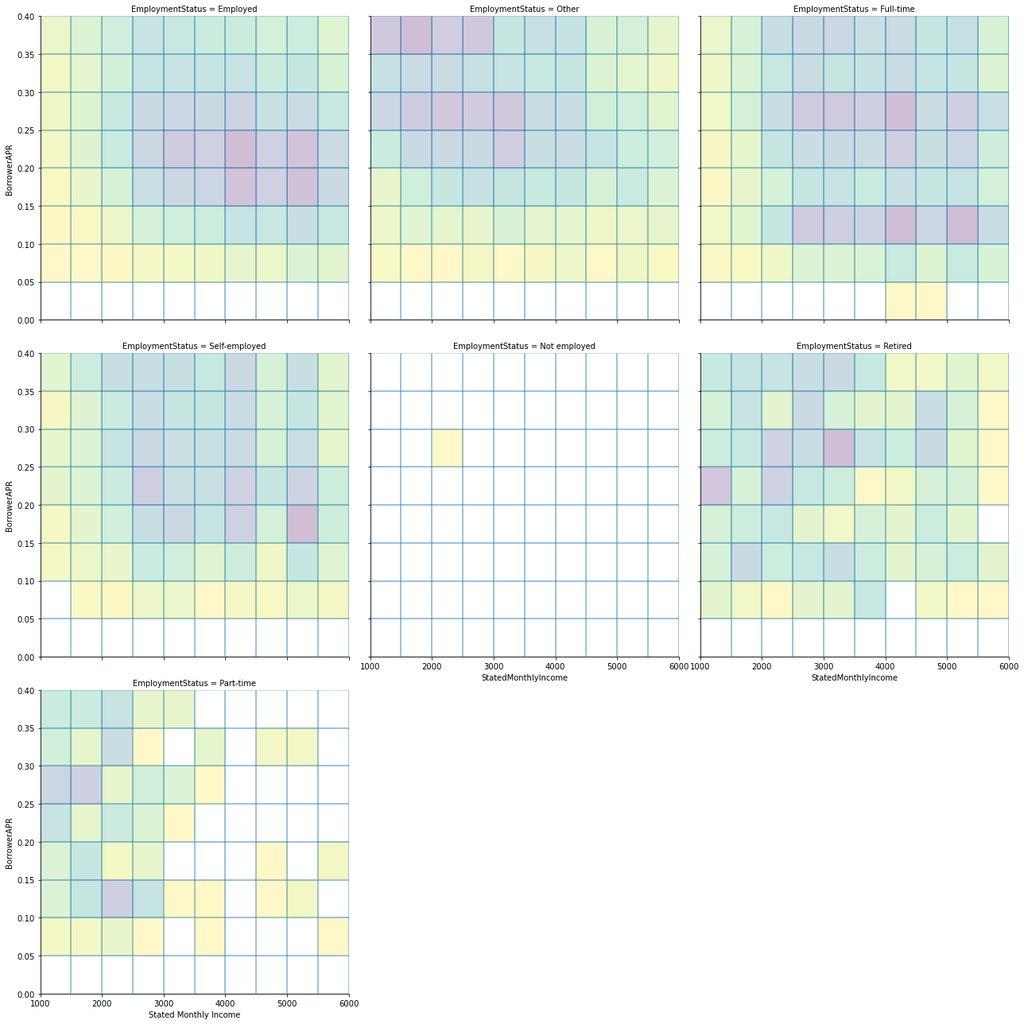

```python
# multivariate plot
bins_x = np.arange(0, 7000 + 500, 500)
bins_y = np.arange(0, 0.4 + 0.05, 0.05)
g = sb.FacetGrid(data = df, col = 'EmploymentStatus', height = 6,
                margin_titles = True, col_wrap = 3)
g.map(plt.hist2d, 'StatedMonthlyIncome', 'BorrowerAPR', alpha = 1/4, cmin=0.5, cmap='viridis_r', bins = [bins_x, bins_y])
plt.xlabel('Stated Monthly Income')
plt.ylabel("BorrowerAPR")
plt.xlim(1000,6000)
```

**According to the heatmap, it looks like there's a slight association with the employment status and the received APR given that the monthly income is the same. Full Time employee could get a better APR at a monthly pay of 5000-6000 than a self employed at the same income. The same also applies for full time employees making +$3000 compared to other types of employment status.**

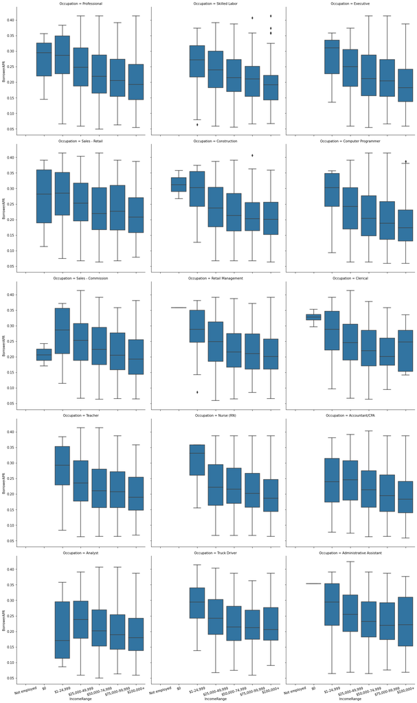

```python
g = sb.FacetGrid(data = df_top15_occupation, col = 'Occupation', height = 6, col_wrap = 3, margin_titles = True)
g.map(sb.boxplot, 'IncomeRange', 'BorrowerAPR')
g.set_xticklabels(rotation=15)
```

As to be expected, with each occupation, the value of the APR appears to go down with each income bracket, and that's more appearant for executives and programmers.

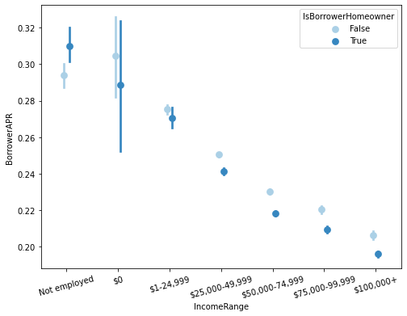

```python
fig = plt.figure(figsize = [8,6])
ax = sb.pointplot(data = df, x = 'IncomeRange', y = 'BorrowerAPR', hue = 'IsBorrowerHomeowner', dodge = 0.1, linestyles = "", palette = 'Blues')
plt.xticks(rotation=15);
```

It appears having a house play a good part in providing lowewr APR

### Talk about some of the relationships you observed in this part of the investigation. Were there features that strengthened each other in terms of looking at your feature(s) of interest?

> The combination of being Full Time employee and with a good occupation and an income will likely draw your APR lower.

### Were there any interesting or surprising interactions between features?

> Owning a home really seem to provide a better APR for the borrower, it could probably boost the trust of the loan investors.